# Estudio sobre la relación entre las tecnologías que usan los desarrolladores en su trabajo y su salud mental

7 de julio del 2023

## Objetivos y datos

### Objetivo principal

> Demostrar que la salud mental del programador depende, en parte, del lenguaje de programación que escoja para trabajar.

### Objetivos secundarios

- Demostrar que la popularidad de un lenguaje de programación no significa que trabajar con este brinde un mejor estado de salud mental.
- Encontrar una relación entre el acceso a información del lenguaje de programación escogido por el programador y su salud mental.
- Encontrar una relación entre el salario que brinda el lenguaje de programación que usan los desarrolladores con su salud mental.
- Demostrar la relación entre el sistema operativo utilizado en el ámbito profesional y la salud mental de los individuos, y encontrar una posible asociación entre los problemas mentales y el tipo de sistema operativo.

### Bases de datos

- Programming language database (PLDB)
- Survey_results 2022 (Stack Overflow)

## Analisis Univariado.

Salario.

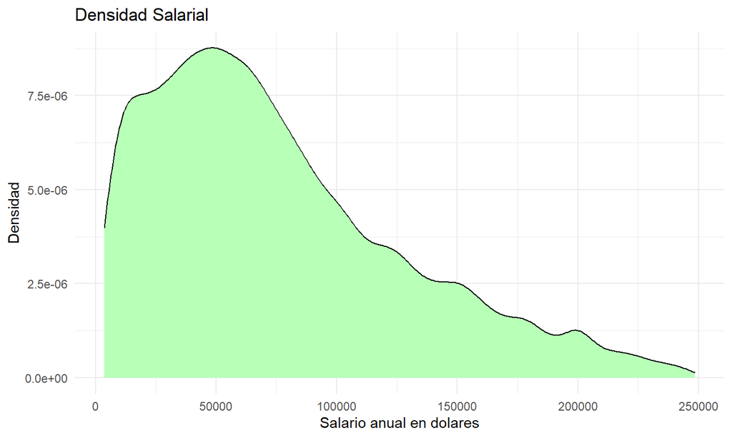

Cantidad de usuarios por lenguaje.

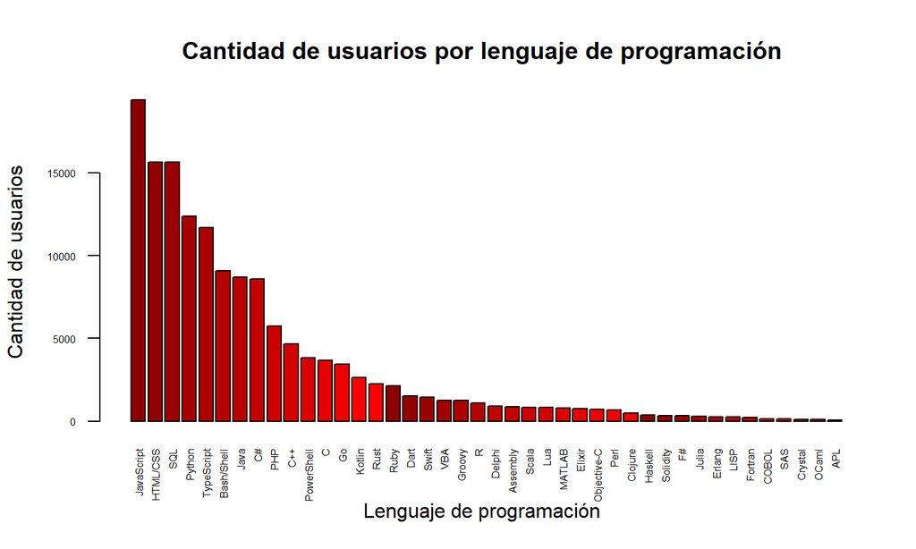

## Analisis bivariado (Salud mental, Lenguaje de programación)

Memoria

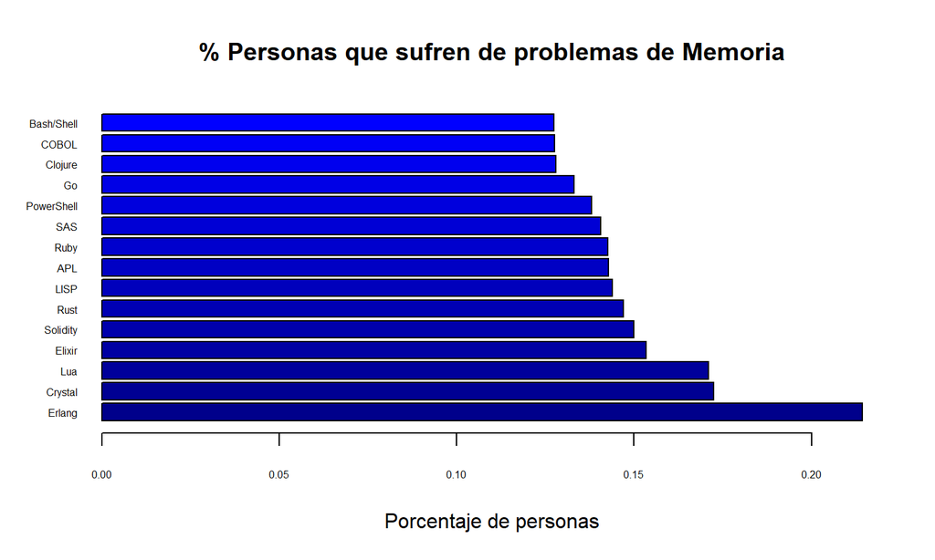

Ansiedad

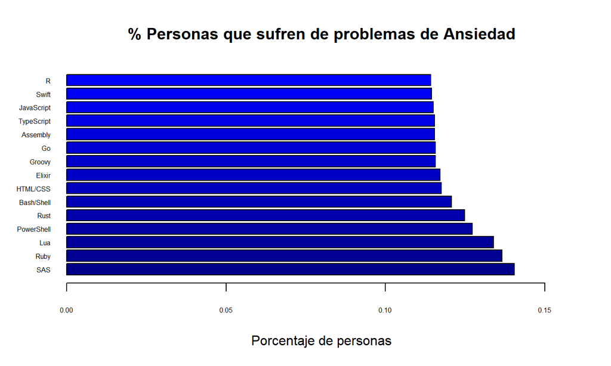

Emocional

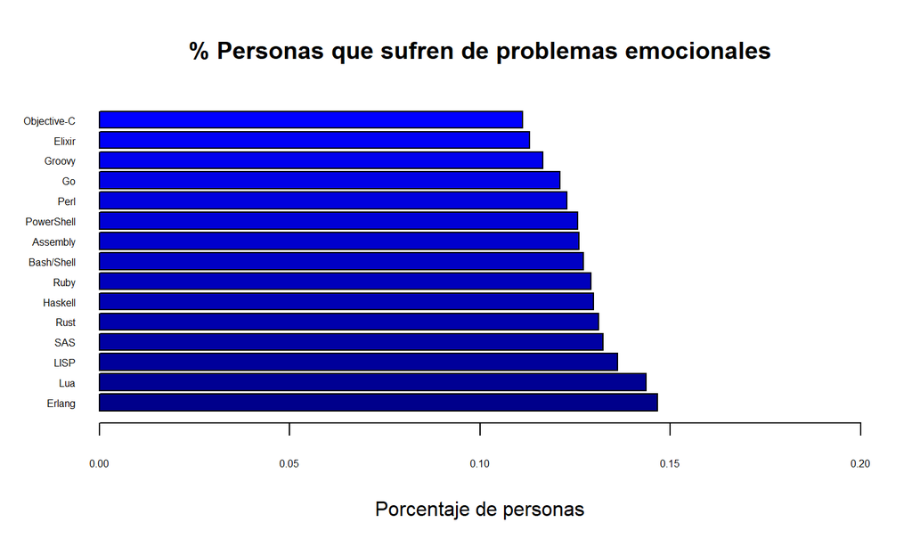

Autismo

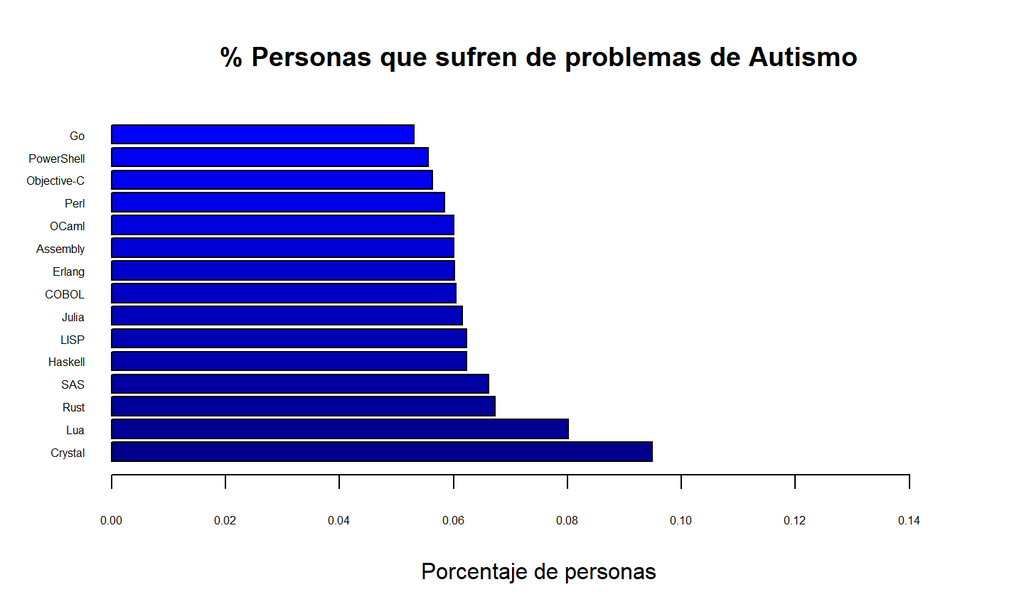

Aprendizaje

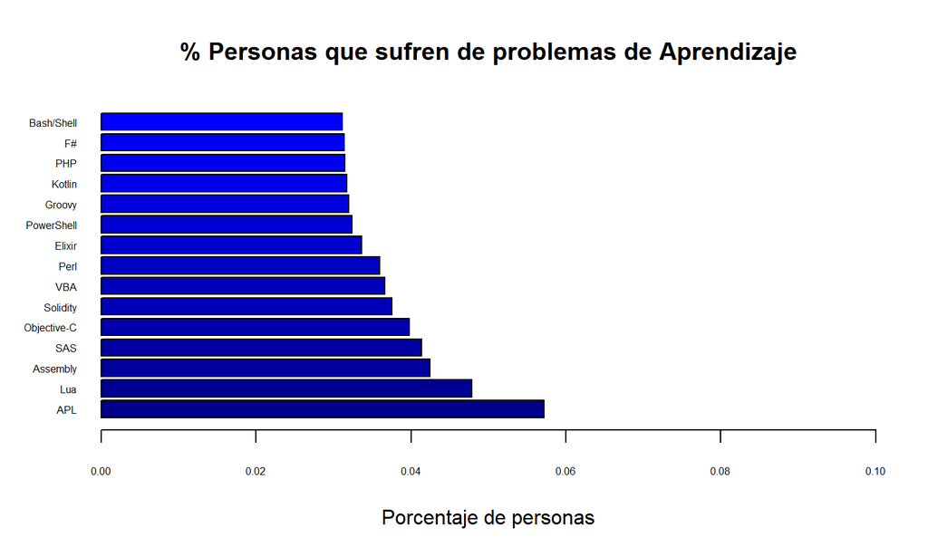

Lenguajes **“problemáticos”**(los tres con más frecuencia en cada problema): [Lua, Crystal, Erlang] U [Lya, Ruby, SAS] U [LISP, Lua, Erlang] U [Rust, Lua, Crystal] U [Assembly, Lua, APL]

> Lua, Crystal, Erlang, Lya, Ruby, SAS, Lisp, Rust, Assembly, APL

## Analisis Bivariado (Salario asociado a un lenguaje, Estado mental)

Promedios

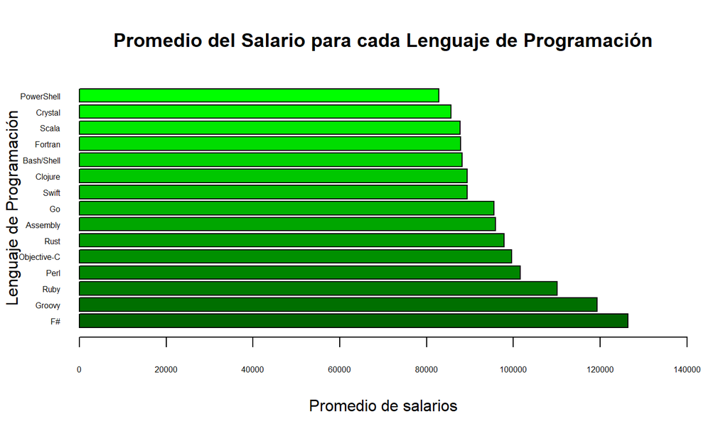

Medianas

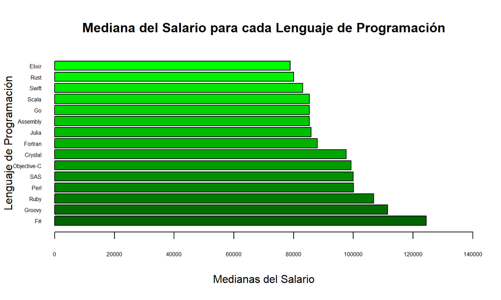

Boxplot (Problemas Mentales | Salario | Enfermedad Mental)

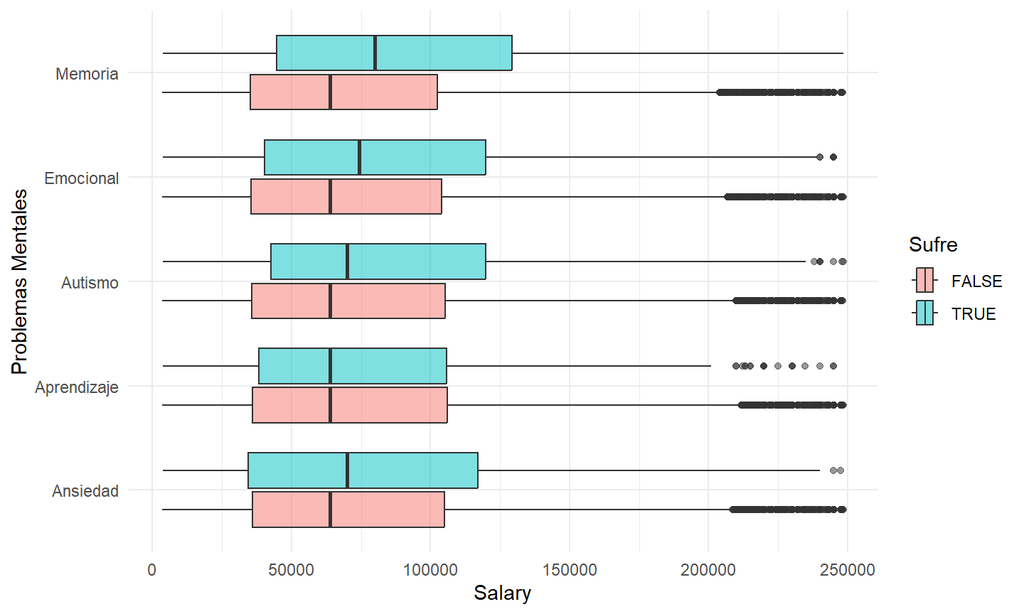

## Variables empíricas

### Cantidad de lenguajes de programación que usa un usuario de Stack Overflow.

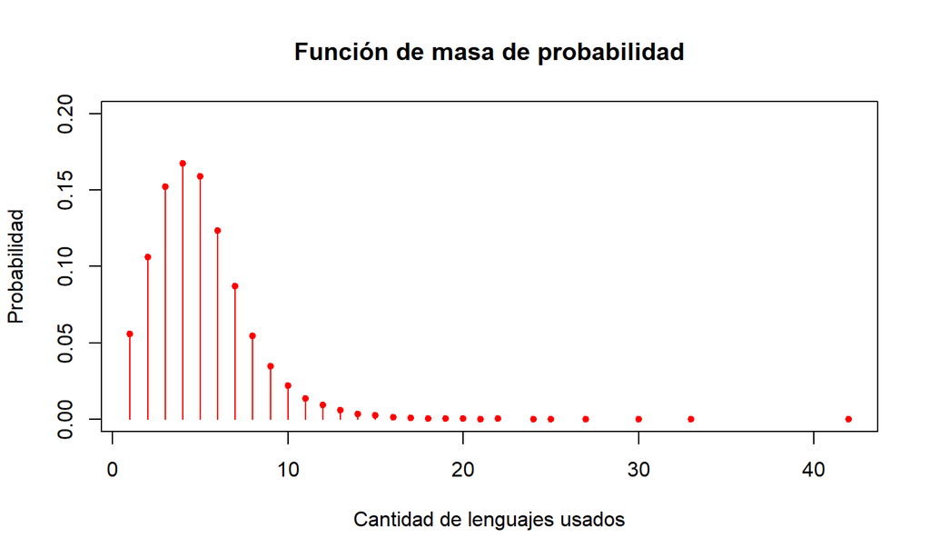

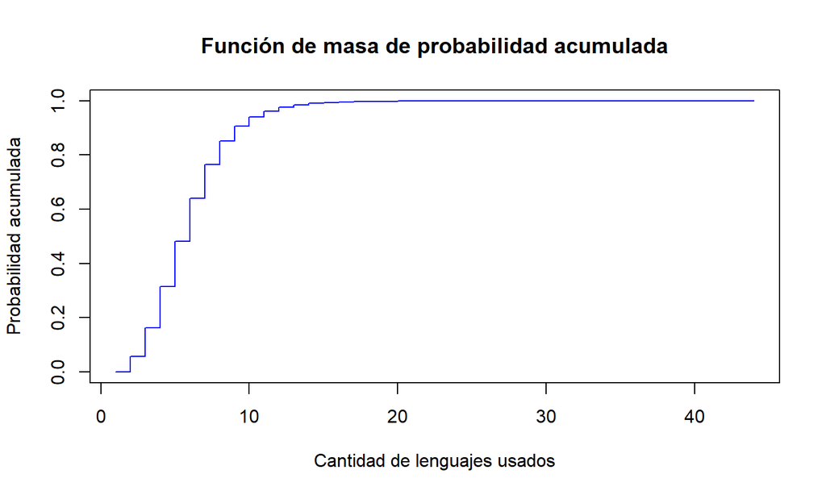

> Media: 4.989317 | Mediana: 5 | \(\sum_{x = \Omega_3} \mathbb{P}(x) = 1\)

### Rangos de edad de un usuario (1 - 6)

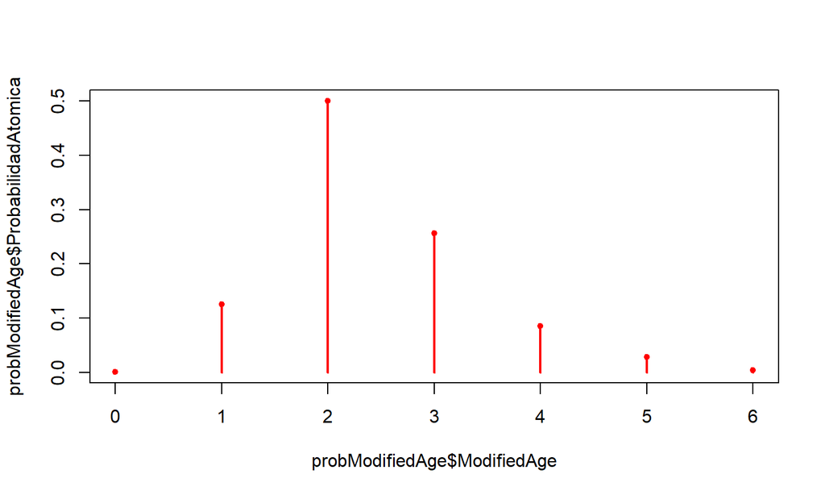

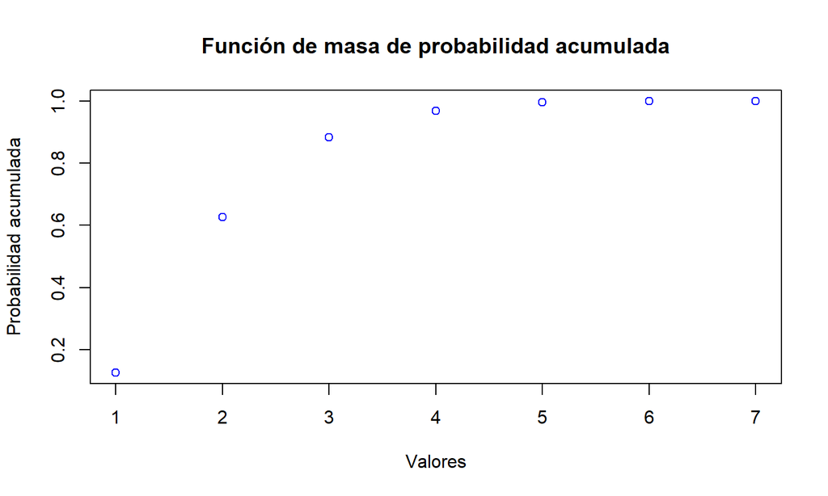

> Media: 2.399192 | Mediana: 2 | \(\sum_{x = \Omega_3} \mathbb{P}(x) = 1\)

## Eventos Dependientes

Seleccionamos los lenguajes que causan más problemas mentales de acuerdo a nuestras gráficas, ya que consideramos que podrían tener una relación interesante. (Lua, Crystal, Erlang, Lya, Ruby, SAS, Lisp, Rust, Assembly, APL)

> E1: Escoger un programador que usa 1 o más de los lenguajes “problemáticos” E2: Escoger un programador que sufre 1 o más problemas mentales

```
## P(E1): 13.79948 %
```

```
## P(E2): 24.41446 %
```

```
## P(E1 ∩ E2): 4.174086 %
```

Se comprueban que las condiciones de independencia no se cumplen, por lo que es dependiente.

```
## P(E2|E1): 0.3024814 != 0.2441446
```

```
## P(E1|E2): 0.1709677 != 0.1379948
```

```
## P(E2)*P(E1) = 0.03369069 != 0.04174086 = P(E1 ∩ E2)
```

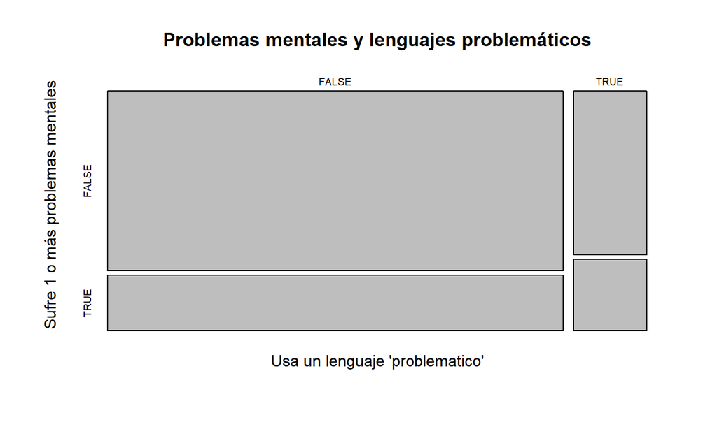

## Eventos Independientes

Se quiere demostrar que nuestra salud mental no depende de si usamos un lenguaje popular o no. Para esto demostraremos que los eventos son independientes:

> E1: Usa un lenguaje que está entre los 5 más populares. E2: Sufre de 2 o más problemas mentales.

```
## P(E1): 93.18244 %
```

```
## P(E2): 9.245309 %
```

```
## P(E1 ∩ E2): 8.735105 %
```

Se comprueban que las condiciones de independencia se cumplen:

```
## P(E1|E2) = 0.9448148 ≈ 0.9318244 = P(E1)
```

```
## P(E2|E1) = 0.09374196 ≈ 0.09245309 = P(E2)
```

```
## P(E1yE2) = 0.08735105 ≈ 0.08615004 = P(E1)*P(E2)
```

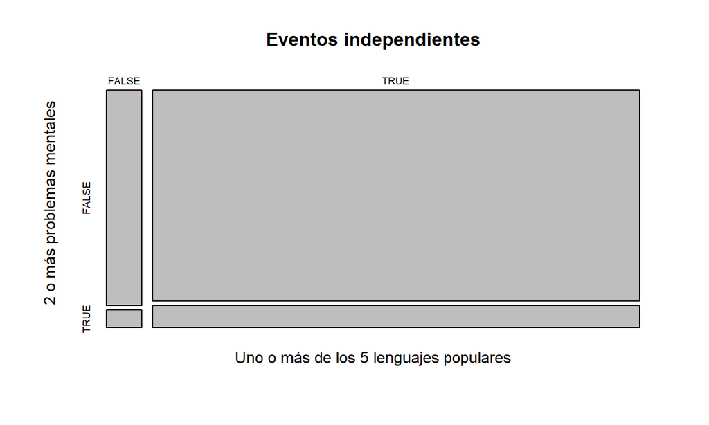

## Distribución Binomial

> Evento: Escoger una muestra de 1000 programadores (con reemplazo) y contar el número de programadores que programen en JavaScript y que ganen mas del promedio.

> Éxito: Que el programador escogido domine en JS y gane mas que el promedio

Realizando el experimento obtenemos el siguiente gráfico:

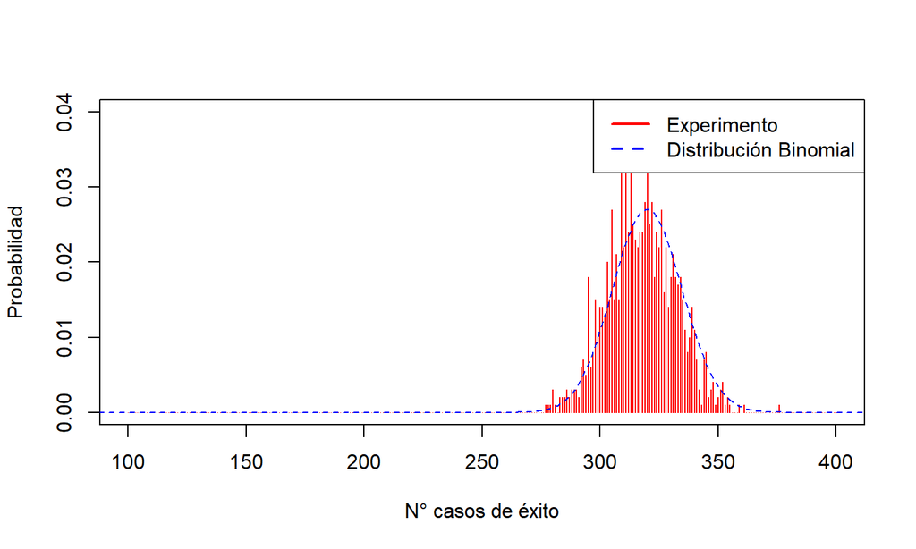

```
## media: 318.2469 | moda: 320 | mediana: 318
```

Sabiendo que los eventos son independientes entre sí y que la mediana, la moda y la media están relativamente cerca. Podemos intuir el uso de un modelo de distribución binomial.

Se puede comprobar el ajuste calculando la Esperanza.

```
## Esperanza = 320 ≈ 318.2469 = Media
```

## Distribución de Poisson

\[ \mathbb{X} = \text{Número de lenguajes mensuales que usa un desarrollador en un mes} \\ Rango(\mathbb{X}) = \mathbb{N} - \{0\} \\ \mathbb{X} \sim \mathcal{Poisson}(\lambda) = \mathcal{Poisson}(5) \]

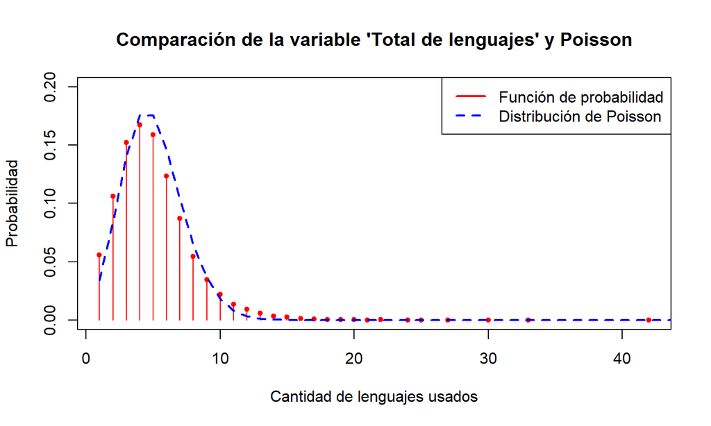

```
## mediana: 5 | media: 4.989317
```